# (homework) 08_Natural_Language_Processing_with_TensorFlow

{% raw %}

🛠 Exercises

1. Rebuild, compile and train model_1, model_2 and model_5 using the Keras Sequential API instead of the Functional API.
2. Retrain the baseline model with 10% of the training data. How does perform compared to the Universal Sentence Encoder model with 10% of the training data?
3. Try fine-tuning the TF Hub Universal Sentence Encoder model by setting training=True when instantiating it as a Keras layer.

We can use this encoding layer in place of our text_vectorizer and embedding layer

```
sentence_encoder_layer = hub.KerasLayer("https://tfhub.dev/google/universal-sentence-encoder/4",
                                        input_shape=[],
                                        dtype=tf.string,
                                        trainable=True) # turn training on to fine-tune the TensorFlow Hub model
```

4. Retrain the best model you've got so far on the whole training set (no validation split). Then use this trained model to make predictions on the test dataset and format the predictions into the same format as the sample_submission.csv file from Kaggle (see the Files tab in Colab for what the sample_submission.csv file looks like). Once you've done this, make a submission to the Kaggle competition, how did your model perform?
5. Combine the ensemble predictions using the majority vote (mode), how does this perform compare to averaging the prediction probabilities of each model?
6. Make a confusion matrix with the best performing model's predictions on the validation set and the validation ground truth labels.

### 1. Rebuild, compile and train model_1, model_2 and model_5 using the Keras Sequential API instead of the Functional API.

I will copy the model of 1, 2 and 5, and then extrapolate it into sequential API. But before that happens, we also need to complete the setup of data on this exercise notebook.

```python
#get helper functions from course
!curl -O https://raw.githubusercontent.com/mrdbourke/tensorflow-deep-learning/main/extras/helper_functions.py

#import helper functions
import sys, os
sys.path.append(os.getcwd())
import sklearn

from helper_functions import unzip_data, create_tensorboard_callback, plot_loss_curves, compare_historys
```

```
  % Total    % Received % Xferd  Average Speed   Time    Time     Time  Current
                                 Dload  Upload   Total   Spent    Left  Speed

  0     0    0     0    0     0      0      0 --:--:-- --:--:-- --:--:--     0
100 10246  100 10246    0     0  24566      0 --:--:-- --:--:-- --:--:-- 24748
```

```python
unzip_data('nlp_getting_started.zip')

# turn .csv files into pandas dataframe
import pandas as pd
train_df = pd.read_csv('train.csv')
test_df = pd.read_csv('test.csv')

# shuffle training dataframe
train_df_shuffled = train_df.sample(frac=1,random_state=35) # shuffle state to 35 for reproducibility
                                    # frac=1 > sample over 100% of data. If say its frac=0.5, shuffle 50%, and drop the other 50% of data

from sklearn.model_selection import train_test_split

# use train test split to split training data into validation as well
train_sentences, val_sentences, train_labels, val_labels = train_test_split(train_df_shuffled['text'].to_numpy(),
                                                                            train_df_shuffled['target'].to_numpy(),
                                                                            test_size=0.1, # dedicate 10% of samples into validation
                                                                            random_state=35) # random state for reproducibility

# setup text vectorization with custom variables
max_vocab_length = 10000 # max number of words to have in our vocabulary
max_length = 15 # max length our sequence will be (e.g. how many words from a Tweet our model will see)

import tensorflow as tf
from tensorflow.keras.layers import TextVectorization
text_vectorizer = TextVectorization(max_tokens=max_vocab_length,
                                    output_mode='int',
                                    output_sequence_length=max_length)

# fit the text vectorizer to the training text
text_vectorizer.adapt(train_sentences)

from tensorflow.keras import layers
```

```python
tf.random.set_seed(35)
from tensorflow.keras import layers

embedding = layers.Embedding(input_dim=max_vocab_length, # set input shape
                             output_dim=128, # set size of embedding vector
                             embeddings_initializer='uniform', # default, initialize randomly
                             input_length=max_length, # how long each input is
                             name='embedding_1')

embedding
```

```
<keras.src.layers.core.embedding.Embedding at 0x1990fa7f580>
```

Let's now check the data head.

```python
import random
random_sentence = random.choice(train_sentences)
print(f'Original text:\n{random_sentence}\
      \n\nVectorized version:')
text_vectorizer([random_sentence])
```

```
Original text:
A traumatised dog that was found buried up to its head in dirt in France is now in safe hands. This is such a... http://t.co/AGQo1479xM

Vectorized version:
```

```
<tf.Tensor: shape=(1, 15), dtype=int64, numpy=
array([[   3,  420, 1081,   15,   23,  221, 4045,   32,    5,   38,  341,
           4, 3077,    4,  953]], dtype=int64)>
```

```python
# view the first 10 training data and it's labels
train_sentences[:10], train_labels[:10]
```

```
(array(['EE recalls Power Bar phone chargers after explosion burns woman \x89ÛÒ The Register http://t.co/lhTvKcoISo',
        '@SterlingKnight  Who had a car crashsterling!Who was driving in the carMel or JoeySterling Knight???????',
        "A little piece I wrote for the Avalanche Designs blog! I'd appreciate it greatly if you checked it out :-)  https://t.co/rfvjh58eF2",
        'Wtf this mom just drowned her child?!',
        "Wreckage 'Conclusively Confirmed' as From MH370: Malaysia PM: Investigators and the families of those who were... http://t.co/2Jr3Yo55dr",
        '#pakistan#news# NANKANA SAHIB City News: Electrocuted From Our Correspondent NANKANA SAHIB: A youth was electr... http://t.co/WERK9qibVV',
        'Video:  Fire burns two apartment buildings and blows up car in Manchester http://t.co/5BGcw3EzB5',
        "@ScottDPierce @billharris_tv @HarrisGle @Beezersun I'm forfeiting this years fantasy football pool out of fear I may win n get my ass kicked",
        '#Saudi Arabia: #Abha: Fatalities reported following suicide bombing at mosque; avoid area http://t.co/1xW0Z8ZeqW',
        'U.S. Forest Service says spending more than half of budget on fires: By Ian Simpson\x89Û_ http://t.co/UyYYrKd6q3'],
       dtype=object),
 array([1, 0, 0, 1, 1, 1, 1, 0, 1, 1], dtype=int64))
```

We will also import the calculation of results to make sure the model has also trained properly

```python
# function for evaluation: accuracy, precision, recall, f1-score
from sklearn.metrics import accuracy_score, precision_recall_fscore_support

def calculate_results(y_true, y_pred):
    '''
    calculates model accuracy, precision, recall, and f1-score of binary class model.

    Args:
    y_true = true labels in the form of a 1D array
    y_pred = predicted labels in the form of a 1D array

    Returns a dictionary of accuracy, recall, precision, f1-score
    '''
    # calculate model accuracy
    model_accuracy = accuracy_score(y_true,y_pred) * 100

    # calculate precision, recall, and f1-score using 'weighted' average
    model_precision, model_recall, model_f1, _ = precision_recall_fscore_support(y_true, y_pred, average='weighted')
    model_results = {'accuracy': model_accuracy,
                     'precision': model_precision,
                     'recall': model_recall,
                     'f1': model_f1}
    return model_results
```

Model 1 sequential:

```python
# also add tensorboard callback - a good habit to build for logging
from helper_functions import create_tensorboard_callback

SAVE_DIR = 'model_logs_homework'
```

```python
# build model 1 sequential
from tensorflow.keras import Sequential

model_1 = Sequential([
    text_vectorizer,
    embedding,
    layers.GlobalAveragePooling1D(),
    layers.Dense(1,activation='sigmoid')
], name='model_1_dense')
```

Time to compile the model

```python
model_1.compile(loss='binary_crossentropy',
                optimizer=tf.keras.optimizers.Adam(),
                metrics=['accuracy'])
```

```python
model_1.summary()
```

```
Model: "model_1_dense"
_________________________________________________________________
 Layer (type)                Output Shape              Param #
=================================================================
 text_vectorization_1 (Text  (None, 15)                0
 Vectorization)

 embedding_1 (Embedding)     (None, 15, 128)           1280000

 global_average_pooling1d_1  (None, 128)               0
  (GlobalAveragePooling1D)

 dense_9 (Dense)             (None, 1)                 129

=================================================================
Total params: 1280129 (4.88 MB)
Trainable params: 1280129 (4.88 MB)
Non-trainable params: 0 (0.00 Byte)
_________________________________________________________________
 Layer (type)                Output Shape              Param #
=================================================================
 text_vectorization_1 (Text  (None, 15)                0
 Vectorization)

 embedding_1 (Embedding)     (None, 15, 128)           1280000

 global_average_pooling1d_1  (None, 128)               0
  (GlobalAveragePooling1D)

 dense_9 (Dense)             (None, 1)                 129

=================================================================
Total params: 1280129 (4.88 MB)
Trainable params: 1280129 (4.88 MB)
Non-trainable params: 0 (0.00 Byte)
_________________________________________________________________
```

```
# functional API model 1
Model: "model_1_dense"
_________________________________________________________________
 Layer (type)                Output Shape              Param #
=================================================================
 input_4 (InputLayer)        [(None, 1)]               0

 text_vectorization_1 (Text  (None, 15)                0
 Vectorization)

 embedding_1 (Embedding)     (None, 15, 128)           1280000

 global_average_pooling1d (  (None, 128)               0
 GlobalAveragePooling1D)

 dense_5 (Dense)             (None, 1)                 129

=================================================================
Total params: 1280129 (4.88 MB)
Trainable params: 1280129 (4.88 MB)
Non-trainable params: 0 (0.00 Byte)
_________________________________________________________________
```

```python
# fit the model
model_1_history = model_1.fit(train_sentences,
                              train_labels,
                              epochs=5,
                              validation_data=(val_sentences,val_labels),
                              callbacks=[create_tensorboard_callback(dir_name=SAVE_DIR, # direct callback to directory save location
                                                                     experiment_name='simple_dense_model')]) # attach name to callback
```

```
Saving TensorBoard log files to: model_logs_homework/simple_dense_model/20260111-230850
```

```python
model_1.evaluate(val_sentences,val_labels)
```

```
[0.4821524918079376, 0.7900262475013733]
```

```
# model 1 functional api evaluation
[0.48308464884757996, 0.7887139320373535]
```

Model 2 sequential:

We'll also form a new embeddings

```python
# embedding model 2
tf.random.set_seed(35)

model_2_embedding = layers.Embedding(input_dim=max_vocab_length,
                                     output_dim=128,
                                     embeddings_initializer='uniform',
                                     input_length=max_length,
                                     name='embedding_2')

model_2 = Sequential([
    text_vectorizer,
    model_2_embedding,
    layers.LSTM(64),
    layers.Dense(1,activation='sigmoid')
], name='model_2_dense')
```

```python
model_2.compile(loss='binary_crossentropy',
                optimizer=tf.keras.optimizers.Adam(),
                metrics=['accuracy'])
```

```python
model_2.summary()
```

```
Model: "model_2_dense"
_________________________________________________________________
 Layer (type)                Output Shape              Param #
=================================================================
 text_vectorization_1 (Text  (None, 15)                0
 Vectorization)

 embedding_2 (Embedding)     (None, 15, 128)           1280000

 lstm_1 (LSTM)               (None, 64)                49408

 dense_10 (Dense)            (None, 1)                 65

=================================================================
Total params: 1329473 (5.07 MB)
Trainable params: 1329473 (5.07 MB)
Non-trainable params: 0 (0.00 Byte)
_________________________________________________________________
_________________________________________________________________
 Layer (type)                Output Shape              Param #
=================================================================
 text_vectorization_1 (Text  (None, 15)                0
 Vectorization)

 embedding_2 (Embedding)     (None, 15, 128)           1280000

 lstm_1 (LSTM)               (None, 64)                49408

 dense_10 (Dense)            (None, 1)                 65

=================================================================
Total params: 1329473 (5.07 MB)
Trainable params: 1329473 (5.07 MB)
Non-trainable params: 0 (0.00 Byte)
_________________________________________________________________
```

```
# model 2 functional api
Model: "model_2_LSTM"
_________________________________________________________________
 Layer (type)                Output Shape              Param #
=================================================================
 input_5 (InputLayer)        [(None, 1)]               0

 text_vectorization_1 (Text  (None, 15)                0
 Vectorization)

 embedding_2 (Embedding)     (None, 15, 128)           1280000

 lstm (LSTM)                 (None, 64)                49408

 dense_6 (Dense)             (None, 1)                 65

=================================================================
Total params: 1329473 (5.07 MB)
Trainable params: 1329473 (5.07 MB)
Non-trainable params: 0 (0.00 Byte)
_________________________________________________________________
```

```python
# Fit model
model_2_history = model_2.fit(train_sentences,
                              train_labels,
                              epochs=5,
                              validation_data=(val_sentences, val_labels),
                              callbacks=[create_tensorboard_callback(SAVE_DIR,
                                                                     "LSTM")])
```

```
Saving TensorBoard log files to: model_logs_homework/LSTM/20260111-230904
```

```python
model_2.evaluate(val_sentences,val_labels)
```

```
[0.7817420363426208, 0.7532808184623718]
```

Model 5 sequential

also creating new embedding

```python
# embedding and model sequential build
tf.random.set_seed(35)
model_5_embedding = layers.Embedding(input_dim=max_vocab_length,
                                     output_dim=128,
                                     embeddings_initializer='uniform',
                                     input_length=max_length,
                                     name='embedding_5')

model_5 = Sequential([
    text_vectorizer,
    model_5_embedding,
    layers.Conv1D(filters=32,kernel_size=5,activation='relu'),
    layers.GlobalMaxPooling1D(),
    layers.Dense(1,activation='sigmoid')
], name='model_5_dense')
```

```python
model_5.compile(loss='binary_crossentropy',
                optimizer=tf.keras.optimizers.Adam(),
                metrics=['accuracy'])
```

```python
model_5.summary()
```

```
Model: "model_5_dense"
_________________________________________________________________
 Layer (type)                Output Shape              Param #
=================================================================
 text_vectorization_1 (Text  (None, 15)                0
 Vectorization)

 embedding_5 (Embedding)     (None, 15, 128)           1280000

 conv1d_1 (Conv1D)           (None, 11, 32)            20512

 global_max_pooling1d_1 (Gl  (None, 32)                0
 obalMaxPooling1D)

 dense_11 (Dense)            (None, 1)                 33

=================================================================
Total params: 1300545 (4.96 MB)
_________________________________________________________________
 Layer (type)                Output Shape              Param #
=================================================================
 text_vectorization_1 (Text  (None, 15)                0
 Vectorization)

 embedding_5 (Embedding)     (None, 15, 128)           1280000

 conv1d_1 (Conv1D)           (None, 11, 32)            20512

 global_max_pooling1d_1 (Gl  (None, 32)                0
 obalMaxPooling1D)

 dense_11 (Dense)            (None, 1)                 33

=================================================================
Total params: 1300545 (4.96 MB)
Trainable params: 1300545 (4.96 MB)
Non-trainable params: 0 (0.00 Byte)
_________________________________________________________________
```

```
# model 5 functional api
Model: "model_5_Conv1D"
_________________________________________________________________
 Layer (type)                Output Shape              Param #
=================================================================
 input_11 (InputLayer)       [(None, 1)]               0

 text_vectorization_1 (Text  (None, 15)                0
 Vectorization)

 embedding_5 (Embedding)     (None, 15, 128)           1280000

 conv1d_1 (Conv1D)           (None, 11, 32)            20512

 global_max_pooling1d_1 (Gl  (None, 32)                0
 obalMaxPooling1D)

 dense_14 (Dense)            (None, 1)                 33

=================================================================
Total params: 1300545 (4.96 MB)
Trainable params: 1300545 (4.96 MB)
Non-trainable params: 0 (0.00 Byte)
_________________________________________________________________
```

```python
# fit the model
model_5_history = model_5.fit(train_sentences,
                              train_labels,
                              epochs=5,
                              validation_data=(val_sentences, val_labels),
                              callbacks=[create_tensorboard_callback(SAVE_DIR, 'Conv1D')])
```

```
Saving TensorBoard log files to: model_logs_homework/Conv1D/20260111-230927
```

```python
model_5.evaluate(val_sentences,val_labels)
```

```
[0.688644528388977, 0.7664042115211487]
```

### 2. Retrain the baseline model with 10% of the training data. How does perform compared to the Universal Sentence Encoder model with 10% of the training data?

Let's split our training dataset 10/90 - thru `train_test_split`, and then recreate baseline model `NB`. Then we will do `USE` 10%.

```python
# split data 10/90
import numpy as np
train_sentences_90, train_sentences_10, train_labels_90, train_labels_10 = train_test_split(np.array(train_sentences),
                                                                                            train_labels,
                                                                                            test_size=0.1,
                                                                                            random_state=35)
```

```python
train_sentences_10.shape, train_labels_10.shape, train_sentences.shape, train_labels.shape
```

```
((686,), (686,), (6851,), (6851,))
```

```python
# recreate model 0 baseline
from sklearn.feature_extraction.text import TfidfVectorizer
from sklearn.naive_bayes import MultinomialNB
from sklearn.pipeline import Pipeline

# Create tokenization and modelling platform
model_0 = Pipeline([
    ('tfidf', TfidfVectorizer()),
    ('clf', MultinomialNB())
])

# fit model
model_0.fit(train_sentences_10,train_labels_10)
```

```
Pipeline(steps=[('tfidf', TfidfVectorizer()), ('clf', MultinomialNB())])
```

```python
# calculate results
baseline_preds = model_0.predict(val_sentences)
baseline_results = calculate_results(val_labels,baseline_preds)
baseline_results
```

```
{'accuracy': 70.60367454068242,
 'precision': 0.7445089038675838,
 'recall': 0.7060367454068242,
 'f1': 0.6814433628867257}
```

Now for the `USE` model with10% data training.

```python
import tensorflow_hub as hub

embed = hub.load('universal-sentence-encoder/tensorFlow2/universal-sentence-encoder/2')
embed_samples = embed(['gay boi',
                       "When you call the universal sentence encoder on a sentence, it turns it into numbers."])
print(embed_samples[0][:50])
```

```
tf.Tensor(
[ 1.1375002e-02 -1.8843573e-02  5.6068316e-02  5.7437051e-02
  6.5281741e-02  4.2217530e-02  1.4778441e-02 -3.1570021e-02
  5.9177954e-02  4.6177451e-02  2.6152678e-02 -5.4112703e-02
  9.9804234e-03 -4.9444895e-02  3.6008745e-02 -9.1622137e-02
 -4.5384888e-02  4.9292047e-02 -2.0187931e-02 -8.5883170e-02
 -4.5254249e-02 -1.7189983e-02 -6.1894325e-03 -4.7443058e-02
  8.2055079e-03  2.1167642e-02 -2.4052041e-02 -5.6918520e-02
 -3.8178362e-02  4.5500048e-02  2.0096451e-02 -9.0327775e-03
  1.5219463e-02 -6.5543868e-02 -5.2185759e-02 -4.0717013e-03
 -3.1089997e-02  2.2612818e-02 -4.6870131e-02  6.0146697e-02
  2.9671106e-02  8.7474640e-03 -3.6036994e-03 -2.1651780e-02
  3.8307600e-02 -4.1706197e-02 -1.5988924e-02 -3.1216638e-03
  6.2471612e-05  5.3457394e-02], shape=(50,), dtype=float32)
```

```python
embed_samples.shape
```

```
TensorShape([2, 512])
```

```python
# create sentence encoder layer for vector/embedding of text
sentence_encoder_layer = hub.KerasLayer('universal-sentence-encoder/tensorFlow2/universal-sentence-encoder/2',
                                        input_shape=[], # shape of inputs coming to model
                                        dtype=tf.string, # type of data to expect
                                        trainable=False, # treating model as feature extraction
                                        name='USE')
```

```python
# create model
model_7 = tf.keras.Sequential([
    sentence_encoder_layer,
    layers.Dense(64,activation='relu'),
    layers.Dense(1,activation='sigmoid')],
    name='model_7')

# compile
model_7.compile(loss='binary_crossentropy',
                optimizer=tf.keras.optimizers.Adam(),
                metrics=['accuracy'])

model_7.summary()
```

```
Model: "model_7"
_________________________________________________________________
 Layer (type)                Output Shape              Param #
=================================================================
 USE (KerasLayer)            (None, 512)               256797824

 dense_3 (Dense)             (None, 64)                32832

 dense_4 (Dense)             (None, 1)                 65

=================================================================
Total params: 256830721 (979.73 MB)
Trainable params: 32897 (128.50 KB)
Non-trainable params: 256797824 (979.61 MB)
_________________________________________________________________
 Layer (type)                Output Shape              Param #
=================================================================
 USE (KerasLayer)            (None, 512)               256797824

 dense_3 (Dense)             (None, 64)                32832

 dense_4 (Dense)             (None, 1)                 65

=================================================================
Total params: 256830721 (979.73 MB)
Trainable params: 32897 (128.50 KB)
Non-trainable params: 256797824 (979.61 MB)
_________________________________________________________________
```

```python
model_7_summary = model_7.fit(train_sentences_10,
                              train_labels_10,
                              epochs=5,
                              validation_data=(val_sentences,val_labels),
                              callbacks=[create_tensorboard_callback(SAVE_DIR, 'tf_hub_sentence_encoder')])
```

```
Saving TensorBoard log files to: model_logs_homework/tf_hub_sentence_encoder/20260107-222613
```

Now let's finally check scores for this model

```python
# check model scores
use_10_preds = model_7.predict(val_sentences)
use_10_results = calculate_results(val_labels,tf.squeeze(tf.round(use_10_preds)))
use_10_results
```

```
{'accuracy': 80.0524934383202,
 'precision': 0.8013579912257222,
 'recall': 0.800524934383202,
 'f1': 0.7988903783803042}
```

```
# multinomial nb 10% scores:
{'accuracy': 70.60367454068242,
 'precision': 0.7445089038675838,
 'recall': 0.7060367454068242,
 'f1': 0.6814433628867257}
```

Obviously our `USE` transfer learning is better at prediction, with the only tradeoff of being multitudes longer at training time compared to our simple `NB` model.

### 3. Try fine-tuning the TF Hub Universal Sentence Encoder model by setting training=True when instantiating it as a Keras layer.

So we will copy back our USE model, and make sure our trainable is `True`.

```python
# fine tuned version of USE
sentence_encoder_finetune = hub.KerasLayer('universal-sentence-encoder/tensorFlow2/universal-sentence-encoder/2',
                                           input_shape=[],
                                           dtype=tf.string,
                                           trainable=True,
                                           name='USE_finetune')
```

```python
# create model
finetune_model = tf.keras.Sequential([
    sentence_encoder_finetune,
    layers.Dense(64,activation='relu'),
    layers.Dense(1,activation='sigmoid')],
    name='finetune_model')

finetune_model.compile(loss='binary_crossentropy',
                       optimizer=tf.keras.optimizers.Adam(),
                       metrics=['accuracy'])

finetune_model.summary()
```

```
Model: "finetune_model"
_________________________________________________________________
 Layer (type)                Output Shape              Param #
=================================================================
 USE_finetune (KerasLayer)   (None, 512)               256797824

 dense_7 (Dense)             (None, 64)                32832

 dense_8 (Dense)             (None, 1)                 65

=================================================================
Total params: 256830721 (979.73 MB)
_________________________________________________________________
 Layer (type)                Output Shape              Param #
=================================================================
 USE_finetune (KerasLayer)   (None, 512)               256797824

 dense_7 (Dense)             (None, 64)                32832

 dense_8 (Dense)             (None, 1)                 65

=================================================================
Total params: 256830721 (979.73 MB)
Trainable params: 256830721 (979.73 MB)
Non-trainable params: 0 (0.00 Byte)
_________________________________________________________________
```

```python
# fit model on whole data
finetune_model_summary = finetune_model.fit(train_sentences,
                                            train_labels,
                                            epochs=5,
                                            validation_data=(val_sentences,val_labels),
                                            callbacks=[create_tensorboard_callback(SAVE_DIR, 'tf_hub_snetence_encoder_finetune')])
```

```
Saving TensorBoard log files to: model_logs_homework/tf_hub_snetence_encoder_finetune/20260111-110501
```

[output not shown]

[output cut: 55 more lines]

[output not shown]

Oops, this training is going to take forever - I'll move the code into `Googlecolab` and do the training there so I can use their GPU, then export the trained model.

```
Saving TensorBoard log files to: model_logs/tf_hub_snetence_encoder_finetune/20260110-223508
Epoch 1/5
215/215 ━━━━━━━━━━━━━━━━━━━━ 12s 15ms/step - accuracy: 0.7679 - loss: 0.5696 - val_accuracy: 0.8018 - val_loss: 0.4372
Epoch 2/5
215/215 ━━━━━━━━━━━━━━━━━━━━ 2s 11ms/step - accuracy: 0.8094 - loss: 0.4223 - val_accuracy: 0.8058 - val_loss: 0.4254
Epoch 3/5
215/215 ━━━━━━━━━━━━━━━━━━━━ 3s 12ms/step - accuracy: 0.8194 - loss: 0.4063 - val_accuracy: 0.8097 - val_loss: 0.4232
Epoch 4/5
215/215 ━━━━━━━━━━━━━━━━━━━━ 3s 12ms/step - accuracy: 0.8251 - loss: 0.3968 - val_accuracy: 0.8097 - val_loss: 0.4229
Epoch 5/5
215/215 ━━━━━━━━━━━━━━━━━━━━ 4s 18ms/step - accuracy: 0.8255 - loss: 0.3892 - val_accuracy: 0.8110 - val_loss: 0.4231
```

But what is weird is the summary of model is completely different:

```
Model: "finetune_model"
┏━━━━━━━━━━━━━━━━━━━━━━━━━━━━━━━━━┳━━━━━━━━━━━━━━━━━━━━━━━━┳━━━━━━━━━━━━━━━┓
┃ Layer (type)                    ┃ Output Shape           ┃       Param # ┃
┡━━━━━━━━━━━━━━━━━━━━━━━━━━━━━━━━━╇━━━━━━━━━━━━━━━━━━━━━━━━╇━━━━━━━━━━━━━━━┩
│ input_layer_10 (InputLayer)     │ (None)                 │             0 │
├─────────────────────────────────┼────────────────────────┼───────────────┤
│ use_layer_2 (USELayer)          │ (None, 512)            │             0 │
├─────────────────────────────────┼────────────────────────┼───────────────┤
│ dense_3 (Dense)                 │ (None, 64)             │        32,832 │
├─────────────────────────────────┼────────────────────────┼───────────────┤
│ dense_4 (Dense)                 │ (None, 1)              │            65 │
└─────────────────────────────────┴────────────────────────┴───────────────┘
 Total params: 32,897 (128.50 KB)
 Trainable params: 32,897 (128.50 KB)
 Non-trainable params: 0 (0.00 B)
```

So I am inclined to not believe the results produced by the model is even accurate because of non present parameters. I've been troubleshooting it, with the keras 3/tf incompatibility, and trying to get it to read the params, it aint worth my time no more. So this will have to do.

### 4. Retrain the best model you've got so far on the whole training set (no validation split). Then use this trained model to make predictions on the test dataset and format the predictions into the same format as the sample_submission.csv file from Kaggle (see the Files tab in Colab for what the sample_submission.csv file looks like). Once you've done this, make a submission to the Kaggle competition, how did your model perform?

We will retrain best model, which is just `USE` model but feature engineering. Since training time is short, I will try running the model for 50 epochs instead of 5.

We will also reimport train data frame, into full sentence/label dataset. So training and validation is combined.

```python
full_sentences = train_df_shuffled['text'].to_numpy()
full_labels = train_df_shuffled['target'].to_numpy()
```

```python
model_7_summary = model_7.fit(full_sentences,
                              full_labels,
                              epochs=50,
                              validation_data=(val_sentences,val_labels),
                              callbacks=[create_tensorboard_callback(SAVE_DIR, 'tf_hub_sentence_encoder')])
```

```
Saving TensorBoard log files to: model_logs_homework/tf_hub_sentence_encoder/20260111-123049
```

Let's then make prediction on the test dataset, and export it to the `.csv` file's format for submission.

```python
test_sentences = test_df['text'].to_list()
test_sentences[:10]
```

```
['Just happened a terrible car crash',
 'Heard about #earthquake is different cities, stay safe everyone.',
 'there is a forest fire at spot pond, geese are fleeing across the street, I cannot save them all',
 'Apocalypse lighting. #Spokane #wildfires',
 'Typhoon Soudelor kills 28 in China and Taiwan',
 "We're shaking...It's an earthquake",
 "They'd probably still show more life than Arsenal did yesterday, eh? EH?",
 'Hey! How are you?',
 'What a nice hat?',
 'Fuck off!']
```

The export format in `.csv` looks like this:

```
id,target
0,0
2,0
3,0
9,0
11,0
12,0
21,0
22,0
27,0
29,0
```

Let's make prediction on test data

```python
# test data prediction
test_prediction = tf.round(tf.squeeze(model_7.predict(test_sentences)))
test_prediction[:10]
```

```
<tf.Tensor: shape=(10,), dtype=float32, numpy=array([0., 1., 1., 1., 1., 0., 0., 0., 0., 0.], dtype=float32)>
```

Recreate the csv file

```python
id = test_df['id'].to_list()
id[:10]
```

```
[0, 2, 3, 9, 11, 12, 21, 22, 27, 29]
```

```python
submission_df = pd.DataFrame({
    'id': id,
    'target': tf.cast(test_prediction,tf.int32)
})

submission_df.to_csv('target.csv',index=False)
```

Let's finally check the file:

```
id,target
0,0
2,1
3,1
9,1
11,1
12,0
21,0
22,0
27,0
29,0
```

Looks to be the right format. It's time to upload them.

[figure not shown]

### 5. Combine the ensemble predictions using the majority vote (mode), how does this perform compare to averaging the prediction probabilities of each model?

To complete that, we will use all models that we have created so far by getting it's prediction after rounding the prediction probabilities, add them together then dividing by the number of models used, then round them again.

This should work like majority vote, as the number >0.5, meant over 50% of the model picked `1` over `0`.

```python
# get model prediction probs
model_1_pred_probs = model_1.predict(val_sentences)
model_2_pred_probs = model_2.predict(val_sentences)
model_5_pred_probs = model_5.predict(val_sentences)
```

```python
# get all model predictions and round them to 0 and 1
use_10_pred_probs = use_10_preds # rename correcting, as this was prediction probability
model_1_preds = tf.squeeze(tf.round(model_1_pred_probs))
model_2_preds = tf.squeeze(tf.round(model_2_pred_probs))
model_5_preds = tf.squeeze(tf.round(model_5_pred_probs))
```

```python
use_10_preds = tf.squeeze(tf.round(use_10_pred_probs))
baseline_preds[:10], use_10_preds[:10], model_1_preds[:10], model_2_preds[:10], model_5_preds[:10]
```

```
(array([1, 0, 0, 0, 0, 0, 0, 0, 0, 0], dtype=int64),
 <tf.Tensor: shape=(10,), dtype=float32, numpy=array([1., 0., 0., 0., 0., 1., 0., 0., 1., 0.], dtype=float32)>,
 <tf.Tensor: shape=(10,), dtype=float32, numpy=array([1., 0., 0., 0., 0., 1., 0., 0., 1., 0.], dtype=float32)>,
 <tf.Tensor: shape=(10,), dtype=float32, numpy=array([1., 0., 0., 0., 0., 1., 0., 0., 1., 0.], dtype=float32)>,
 <tf.Tensor: shape=(10,), dtype=float32, numpy=array([1., 0., 0., 0., 0., 1., 0., 0., 1., 0.], dtype=float32)>)
```

We've got all 5 model predictions binaries. Now we'd need to make sure they're all same data type and integer, not floats. We'll convert data to Numpy array int.

```python
# convert preds to numpy int array
use_10_preds = use_10_preds.numpy().astype(int)
model_1_preds = model_1_preds.numpy().astype(int)
model_2_preds = model_2_preds.numpy().astype(int)
model_5_preds = model_5_preds.numpy().astype(int)

use_10_preds[:10], model_1_preds[:10], model_2_preds[:10], model_5_preds[:10]
```

```
(array([1, 0, 0, 0, 0, 1, 0, 0, 1, 0]),
 array([1, 0, 0, 0, 0, 1, 0, 0, 1, 0]),
 array([1, 0, 0, 0, 0, 1, 0, 0, 1, 0]),
 array([1, 0, 0, 0, 0, 1, 0, 0, 1, 0]))
```

Put all prediction arrays into one list

```python
pred_list = [baseline_preds,use_10_preds,model_1_preds,model_2_preds,model_5_preds]
pred_matrix = np.stack(pred_list,axis=0) # stack our list of predictions, rather than appending from the end of it
pred_matrix
```

```
array([[1, 0, 0, ..., 0, 0, 0],
       [1, 0, 0, ..., 1, 1, 0],
       [1, 0, 0, ..., 1, 1, 0],
       [1, 0, 0, ..., 1, 1, 0],
       [1, 0, 0, ..., 1, 1, 0]], dtype=int64)
```

Create majority vote cod from stacked numpy array

```python
# figure out the numbers
pred_matrix.sum(axis=0)[:10],pred_matrix.shape[0]
```

```
(array([5, 0, 0, 0, 0, 4, 0, 0, 4, 0], dtype=int64), 5)
```

.sum(axis=0) sums up the number, whilst on axis 0, by summing on the row of matrix when reaching the same index.

.shape[0] gets the shape number of row length.

```python
# majority vote code
majority_vote = (pred_matrix.sum(axis=0) >= (pred_matrix.shape[0]/2)).astype(int)
# have to convert to integer, as it gives True False boolean
print(majority_vote[:10])
```

```
[1 0 0 0 0 1 0 0 1 0]
```

Make prediction

```python
baseline_results = calculate_results(val_labels,majority_vote)
baseline_results
```

```
{'accuracy': 79.26509186351706,
 'precision': 0.7945205385015361,
 'recall': 0.7926509186351706,
 'f1': 0.7903183243034217}
```

```
# USE transfer learning model on 10% of data
{'accuracy': 80.0524934383202,
 'precision': 0.8013579912257222,
 'recall': 0.800524934383202,
 'f1': 0.7988903783803042}
```

Majority of the prediction is not the best - most likely because the other NLP basic model trained from the beginning, outweighs the transfer learning model USE.

Now time to find the average prediction probability over all models. Let's redo all the numbers and prediction list.

```python
use_10_pred_probs = model_7.predict(val_sentences)
baseline_preds[:10], use_10_pred_probs[:10], model_1_pred_probs[:10], model_2_pred_probs[:10], model_5_pred_probs[:10]
```

```
(array([1, 0, 0, 0, 0, 0, 0, 0, 0, 0], dtype=int64),
 array([[9.9929804e-01],
        [1.2710119e-02],
        [7.8240359e-01],
        [8.5931318e-03],
        [3.3440290e-05],
        [9.9906540e-01],
        [2.0090826e-03],
        [1.0496043e-02],
        [1.1372198e-01],
        [9.0467882e-01]], dtype=float32),
 array([[0.9440335 ],
        [0.08890832],
        [0.19989282],
        [0.05887891],
        [0.16172898],
        [0.8279361 ],
        [0.17234242],
        [0.01283292],
        [0.6412949 ],
        [0.21639164]], dtype=float32),
 array([[0.9995312 ],
        [0.17190781],
        [0.48009658],
        [0.02884044],
        [0.07799546],
        [0.9993023 ],
        [0.11407737],
        [0.01895308],
        [0.8016162 ],
        [0.13591291]], dtype=float32),
 array([[0.93117785],
        [0.06289595],
        [0.04210205],
        [0.00255701],
        [0.01472924],
        [0.78172237],
        [0.05973373],
        [0.01064789],
        [0.9953833 ],
        [0.02597033]], dtype=float32))
```

our baseline model only does `0` and `1`, and not probabilities, so it'll have to stay as it is

do the .squeeze to remove extra unneeded dims

```python
use_10_pred_probs=np.squeeze(use_10_pred_probs)
model_1_pred_probs=np.squeeze(model_1_pred_probs)
model_2_pred_probs=np.squeeze(model_2_pred_probs)
model_5_pred_probs=np.squeeze(model_5_pred_probs)
baseline_preds[:10], use_10_pred_probs[:10], model_1_pred_probs[:10], model_2_pred_probs[:10], model_5_pred_probs[:10]
```

```
(array([1, 0, 0, 0, 0, 0, 0, 0, 0, 0], dtype=int64),
 array([9.9929804e-01, 1.2710119e-02, 7.8240359e-01, 8.5931318e-03,
        3.3440290e-05, 9.9906540e-01, 2.0090826e-03, 1.0496043e-02,
        1.1372198e-01, 9.0467882e-01], dtype=float32),
 array([0.9440335 , 0.08890832, 0.19989282, 0.05887891, 0.16172898,
        0.8279361 , 0.17234242, 0.01283292, 0.6412949 , 0.21639164],
       dtype=float32),
 array([0.9995312 , 0.17190781, 0.48009658, 0.02884044, 0.07799546,
        0.9993023 , 0.11407737, 0.01895308, 0.8016162 , 0.13591291],
       dtype=float32),
 array([0.93117785, 0.06289595, 0.04210205, 0.00255701, 0.01472924,
        0.78172237, 0.05973373, 0.01064789, 0.9953833 , 0.02597033],
       dtype=float32))
```

```python
pred_prob_list = [baseline_preds,use_10_pred_probs,model_1_pred_probs,model_2_pred_probs,model_5_pred_probs]
pred_prob_matrix = np.stack(pred_prob_list,axis=0) # stack our list of predictions, rather than appending from the end of it
pred_prob_matrix
```

```
array([[1.        , 0.        , 0.        , ..., 0.        , 0.        ,
        0.        ],
       [0.99929804, 0.01271012, 0.78240359, ..., 0.91181636, 0.99932879,
        0.01020257],
       [0.9440335 , 0.08890832, 0.19989282, ..., 0.68400186, 0.97957259,
        0.0521355 ],
       [0.99953121, 0.17190781, 0.48009658, ..., 0.77998215, 0.99945724,
        0.05163565],
       [0.93117785, 0.06289595, 0.04210205, ..., 0.96852088, 0.99789286,
        0.00146028]])
```

Redo majority vote code, so its average - via the pred_prob_matrix

```python
# average val
average_val = (pred_prob_matrix.sum(axis=0) >= (pred_prob_matrix.shape[0]/2)).astype(int)
# have to convert to integer, as it gives True False boolean
print(average_val[:10])
```

```
[1 0 0 0 0 1 0 0 1 0]
```

```python
baseline_results = calculate_results(val_labels,average_val)
baseline_results
```

```
{'accuracy': 83.85826771653542,
 'precision': 0.8433806807504004,
 'recall': 0.8385826771653543,
 'f1': 0.8363842362800337}
```

```
# majority vote performance
{'accuracy': 79.26509186351706,
 'precision': 0.7945205385015361,
 'recall': 0.7926509186351706,
 'f1': 0.7903183243034217}
```

Average prediction over the 5 models actuallly did surprisingly well when it's just the adding of predictions are different.

### 6. Make a confusion matrix with the best performing model's predictions on the validation set and the validation ground truth labels.

To do this, we can import the `make_confusion_matrix` from our `helper_functions`.

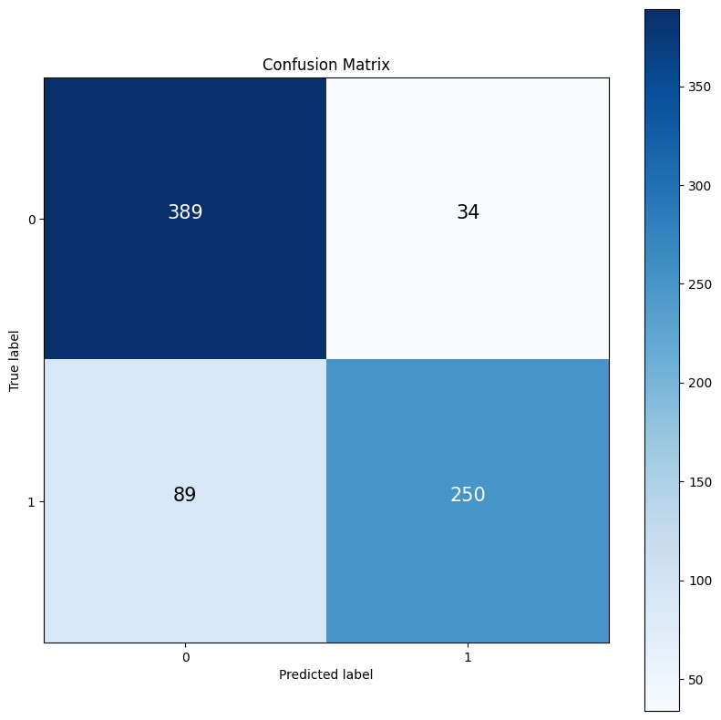

```python
from helper_functions import make_confusion_matrix

make_confusion_matrix(y_true=val_labels,
                      y_pred=average_val,
                      norm=False,
                      )
```

Based on the confusion matrix, our model ensemble average have a bit of a harder time, picking up `disaster` tweets compared to `non disaster` tweets.

{% endraw %}